# Computational Documents

개요서(Compendium) 시작하며

xwMOOC

2019-12-28

# 1 시작점

Robert Gentleman과 Duncan Temple Lang이 2004년 발표한 논문에서 공식적인 시작점을 찾을 수 있다.[^1] [^2]

> We introduce the concept of a compendium as both a container for the different elements that make up the document and its computations (i.e. text, code, data,…), and as a means for distributing, managing and updating the collection. - Gentleman, R. and Temple Lang, D. (2004)

R packages can serve as **research compendia** (including code, data and outputs) for reproducible data analysis projects

R 팩키지는 재현가능한 데이터 분석 프로젝트를 위한 **연구 개요서(research compendia)**로 훌륭한 대안으로 역할을 수행할 수 있다. 연구 개요서는 코드, 데이터, 출력결과물 등이 포함된다.

# 2 논문과 `ropensci` 진행경과

[Ben Marwick, Carl Boettiger, Lincoln Mullen (2018), “Packaging Data Analytical Work Reproducibly Using R (and Friends)”, University of Wollongong Research Online](https://ro.uow.edu.au/cgi/viewcontent.cgi?article=6445&context=smhpapers)

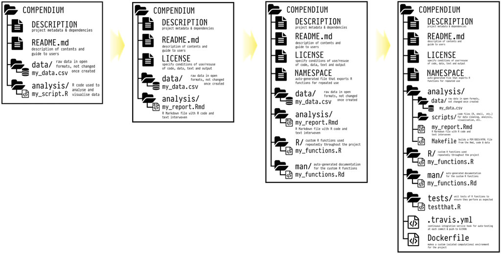

재현가능한 과학연구를 위한 저작 방법

- [`ropensci`, “Community Call: Reproducible Research with R”](https://ropensci.org/commcalls/2019-07-30/)

# 3 R 팩키지와 개요서 [^3] [^4]

R 프로젝트, R 팩키지, 개요서(compendium)가 서로 동일한 목표를 가지고 있지만, 다소 차이가 있는 것도 사실이다. 데이터 사이언스를 하면서 코드, 데이터, 결과물을 하나의 개요서(compendium) 아래 묶어 이를 통해 재현가능한 과학기술 발전을 도모하는 것이 무엇보다 필요하다.

- 좋은 데이터 사이언스 프로젝트 구성
  - 모든 파일은 동일한 디렉토리 아래 정돈되어 있음
  - 원본 데이터(raw data)는 별도 폴더에 잘 저장되어 있어야 함.
  - 정제된 데이터는 R 스크립트를 통해서 만들어져야 함.
  - 함수는 분석 스크립트와 독립되어 저장되어야 함.
  - 함수는 문서화가 잘 되어야 하면 (단위) 테스트도 되어 ㅎ함.
  - 산출물은 코드와 격리되어야 하며 일회용으로 한번 사용하고 버림.
  - `Makefile`은 적절한 순서로 분석을 실행해야 함.
  - README 파일은 프로젝트 개요를 담고 있어야 함.
  - `git`을 사용해서 R 코드와 Rmd 문서 파일은 버전 제어를 해야 함.

```r
project/
|-+ data-raw/   # 원본 데이터
|-+ data/       # (R 스크립트로부터 생성된) 정제된 데이터
|-+ R/          # 함수(Functions)
|-+ man/        # (Roxygen으로 생성된) 함수 문서(Function documentation)
|-+ tests/      # 테스트 (functions, Rmd)
|-+ vignettes/  # (Rmd로 작성된) 분석결과, 원고, 보고서 등
|
|- Makefile    # 자동화 시키는 마스터 스크립트
|- DESCRIPTION # 메타데이터와 의존성
|- README      # 프로젝트 개요서
```

상기와 같이 개요서를 R 팩키지를 통해 구현하게 되면 어떤 점이 좋은지 살펴보자.

- 재현가능성: Reproducibility
- 일관되고, 표준적이며, 물흐르는 듯한 프로젝트 구조: Consistent, standard, streamlined organisation
- 모듈화, 문서화, 테스트 주도 철학을 증진: Promotes modular, well-documented and tested code
- 공유하기 쉬움: Easy to share (zip, GitHub repo)
- 설치와 실행이 쉬움: Easy to install & run (Dependencies)
- R 팩키지 제작 기계: Use R package development machinery:
- R CMD CHECK
- 지속 개발/지속 배포: Continuous integration (Travis-CI)
- goodpractice로 자동화된 코드리뷰: Automatic code review with goodpractice
- pkgdown으로 프로젝트 웹사이트 제작: Easily create project websites with pkgdown

## 3.1 시작이 반이다

- 시작이 반이다 - `start small`

```r
project
|- DESCRIPTION
|- README.md
|- Metadata.txt
|
|- data/
|   +- 2014ParasiteSurveyJustBrood.csv
|   +- CedarBPLifeTable2014.csv
|   +- NorthBPLifeTable2013.txt
|   +- NorthBPLifeTable2014.csv|
|- analysis/
|   +- CodeforBPpaper.R
```

## 3.2 팩키지 개발

- 팩키지 개발

```r
project
|- DESCRIPTION
|- NAMESPACE
|- README.md
|- LakeTrophicModelling.Rproj
|
|- R/
|   +- LakeTrophicModelling-package.r
|   +- class_prob_rf.R
|   +- condAccuracy.R
|   +- crossval_rf.R
|   +- density_plot.R
|   +- ecdf_ks_ci.R
|   +- ecor_map.R
|   +- getCyanoAbund.R
|   +- getLakeIDs.R
|   +- importancePlot.R
|
|- man/
|   +- class_prob_rf.Rd
|   +- condAccuracy.Rd
|   +- crossval_rf.Rd
|   +- density_plot.Rd
|   +- ecdf_ks_ci.Rd
|   +- ecor_map.Rd
|   +- getCyanoAbund.Rd
|   +- getLakeIDs.Rd
|   +- importancePlot.Rd
|
|- data/
|   +- LakeTrophicModelling.rda
|
|- vignettes/
|
|- inst/
|   +- doc/
|      +- manuscript.pdf
|   +- extdata/
|      +- ltmData.csv
|      +- data_def.csv
```

## 3.3 CI/CD와 도커

`Dockerfile` 파일을 추가하여 환경도 재현가능하게 만들 수 있고, `.travis.yml`을 추가하여 CI/CD 환경도 구축할 수 있다. `tests/`를 추가하여 테스트 주도 개발(test-driven development, TDD)를 시도할 수 있고, 이를 통해 수작업 검증을 자동화하여 생산성과 품질을 대폭 향상시킬 수도 있다.

```r
project
|- DESCRIPTION          # project metadata and dependencies
|- README.md            # top-level description of content and guide to users
|- NAMESPACE            # exports R functions in the package for repeated use
|- LICENSE              # specify the conditions of use and reuse of the code, data & text
|- .travis.yml          # continuous integration service hook for auto-testing at each commit
|- Dockerfile           # makes a custom isolated computational environment for the project
|
|- data/                # raw data, not changed once created
|  +- my_data.csv       # data files in open formats such as TXT, CSV, TSV, etc.
|
|- analysis/            # any programmatic code
|  +- my_report.Rmd     # R markdown file with narrative text interwoven with code chunks
|  +- makefile          # builds a PDF/HTML/DOCX file from the Rmd, code, and data files
|  +- scripts/          # code files (R, shell, etc.) used for data cleaning, analysis and visualisation
|
|- R/
|  +- my_functions.R    # custom R functions that are used more than once throughout the project
|
|- man/
|  +- my_functions.Rd   # documentation for the R functions (auto-generated when using devtools)
|
|- tests/
|  +- testthat.R        # unit tests of R functions to ensure they perform as expected
```

# 4 각 사례별 템플릿

- [Jeff Hollister’s manuscriptPackage](https://github.com/jhollist/manuscriptPackage)
- [Carl Boettiger’s template](https://github.com/cboettig/template)
- [Francisco Rodriguez-Sanchez’s template](https://github.com/Pakillo/template)
- [Ben Marwick’s researchcompendium](https://github.com/benmarwick/researchcompendium)
  - [`rrtools`: Tools for Writing Reproducible Research in R](https://github.com/benmarwick/rrtools)

# 5 `rrtoools` 워크샵

- [“Reproducible Research in R with rrtools”, 31st October, Northwest Universities R Day](https://annakrystalli.me/rrtools-repro-research/index.html)
  - 공통: `devtools`
  - 윈도우즈: [Rtools](https://cran.r-project.org/bin/windows/Rtools/)
  - 맥: [Xcode](https://developer.apple.com/xcode/)
  - 리눅스: `r-devel` 혹은 `r-base-dev`
[^1]: “Statistical Analyses and Reproducible Research” Bioconductor Project Working Papers
[^2]: “Reproducible Research: A Bioinformatics Case Study” in Statistical Applications in Genetics and Molecular Biology
[^3]: [jennybc, “Use of an R package to facilitate reproducible research”](https://github.com/ropensci/rrrpkg)
[^4]: [Francisco Rodriguez-Sanchez “Structuring data anlaysis projects as R packages”](https://github.com/Pakillo/template/blob/master/slides/Projects_as_Packages.pdf)